# Grouped Patterns of Heterogeneity in Panel Data: a walkthrough in R

Following Bonhomme and Manresa (2015, *Econometrica*)

Eliot R. Weinstein eliotw@uchicago.edu erweinstein.com

## Credit

The grouped fixed-effects (GFE) estimator, its theory, the algorithms, the empirical application, and the original MATLAB, Fortran, and Stata code are by **Stéphane Bonhomme and Elena Manresa**:

Bonhomme, S. and E. Manresa (2015), “Grouped Patterns of Heterogeneity in Panel Data,” *Econometrica* 83(3), 1147–1184. [doi:10.3982/ECTA11319](https://doi.org/10.3982/ECTA11319)

This document walks through their paper with an R translation of their replication files. The structure of the argument, the notation, and the numbers come from the paper and its Supplementary Appendix. The R translation and this walkthrough are by Eliot R. Weinstein; errors of translation are mine.

# 1 The question

Panel data let us control for unobserved heterogeneity, and the standard way to do so is with unit fixed effects. Fixed effects are time-invariant. In many applications, though, the unobservables we worry about move over time, and they move differently for different units. Bonhomme and Manresa’s application is a clear case: the relationship between income and democracy. In a large cross-country panel, pooled regressions show a strong positive association between lagged income and democracy, and fixed-effects regressions show essentially none (Acemoglu, Johnson, Robinson, and Yared, 2008). A fixed effect absorbs a country’s average level of democracy. It cannot absorb the fact that Spain and Portugal democratized in the 1970s, much of Latin America in the 1980s, and much of Sub-Saharan Africa in the 1990s.

Interactive (factor) fixed effects allow for time-varying unobservables, at the price of many parameters and a bias of order $1/T$ in short panels. Bonhomme and Manresa propose a more parsimonious structure: unobserved heterogeneity varies over time, but countries fall into a small number of groups that share the same time path. Group membership is not known; it is estimated from the data.

# 2 The model and the estimator

For units $i = 1, \dots, N$ and periods $t = 1, \dots, T$,

$$y_{it} = x_{it}'\theta + \alpha_{g_i t} + v_{it},$$

where $g_i \in \{1, \dots, G\}$ is the group of unit $i$, and $\alpha_{gt}$ is the time effect of group $g$ in period $t$. Units in the same group share the same path $(\alpha_{g1}, \dots, \alpha_{gT})$. The grouping $\gamma = \{g_1, \dots, g_N\}$, the paths $\alpha$, and the common coefficients $\theta$ are all parameters.

The GFE estimator minimizes the sum of squared residuals over all three:

$$(\hat\theta, \hat\alpha, \hat\gamma) = \underset{(\theta, \alpha,
\gamma)}{\operatorname{argmin}}
\sum_{i=1}^N \sum_{t=1}^T \left( y_{it} - x_{it}'\theta -
\alpha_{g_i t} \right)^2 .$$

Two observations organize everything that follows.

1. **Given the grouping, the problem is OLS.** With $\gamma$ fixed, $\theta$ and $\alpha$ are the coefficients of a regression of $y_{it}$ on $x_{it}$ and a full set of group-by-period dummies.
2. **Given the parameters, the grouping is a nearest-path assignment.** With $(\theta, \alpha)$ fixed, each unit goes to the group whose path is closest to its own residual path:
   $$\hat g_i(\theta, \alpha) = \underset{g \in
   \{1,\dots,G\}}{\operatorname{argmin}}
   \sum_{t=1}^T \left( y_{it} - x_{it}'\theta - \alpha_{gt} \right)^2 .$$

Without covariates this is exactly the $k$-means problem, with $N$ points in $\mathbb{R}^T$ and $G$ centers. With covariates it is $k$-means in which the points themselves, $y_i - x_i\theta$, depend on the parameter being estimated.

## 2.1 The data

The application uses the five-year balanced panel of Acemoglu et al. (2008): 90 countries observed every five years from 1970 to 2000. The outcome is the Freedom House democracy index (between 0 and 1), and the covariates are lagged democracy and lagged log GDP per capita:

$$\text{dem}_{it} = \theta_1 \, \text{dem}_{i,t-1} + \theta_2 \,
\text{income}_{i,t-1} + \alpha_{g_i t} + v_{it}.$$

The quantity of interest is the cumulative income effect $\theta_2 / (1 - \theta_1)$.

```r
p <- load_bm_panel()
c(N = p$N, T = p$T, K = p$K)
```

```
 N  T  K
90  7  2
```

```r
head(attr(p, "data"), 8)
```

```
  unit code code_numeric year      dem   lag_dem lag_income
1    1  ARG            6 1970 0.166667 0.5300000   9.016160
2    1  ARG            6 1975 0.833333 0.1666667   9.133990
3    1  ARG            6 1980 0.166667 0.8333333   9.202840
4    1  ARG            6 1985 0.833333 0.1666667   9.271142
5    1  ARG            6 1990 1.000000 0.8333333   9.065316
6    1  ARG            6 1995 0.833333 1.0000000   8.884429
7    1  ARG            6 2000 1.000000 0.8333333   9.236609
8    2  AUS            9 1970 1.000000 1.0000000   9.420744
```

The data are stacked unit by unit, as in the original code: row $(i-1)T + t$ holds unit $i$ in period $t$.

# 3 Computation

The number of possible groupings is $G^N$; with $N = 90$ and $G = 4$ that is about $10^{54}$. Exhaustive search is out of the question, so the paper gives two heuristics and an exact method to check them.

## 3.1 Algorithm 1: alternate between the two steps

Start from random $(\theta^{(0)}, \alpha^{(0)})$. Then iterate:

- *assignment*: $g_i^{(s+1)} = \hat g_i(\theta^{(s)}, \alpha^{(s)})$ for every $i$;
- *update*: $(\theta^{(s+1)}, \alpha^{(s+1)})$ = OLS given the grouping $\gamma^{(s+1)}$;

until the grouping no longer changes. Each step weakly lowers the objective, so the algorithm converges, but only to a local minimum. The answer depends on the starting values, which is why the paper runs it from many of them.

```r
set.seed(1)
a1 <- gfe(p, G = 3, algorithm = "alg1", n_starts = 200)
a1
```

```
Grouped fixed-effects estimator (Bonhomme and Manresa, 2015)
  N = 90  T = 7  K = 2  G = 3
  computed with: Algorithm 1 (iterative)
  objective: 16.59872653
  group sizes: 38 28 24
  theta:
   lag_dem lag_income
    0.4065     0.0894
  starts reaching the best objective: 3 of 200 (2%)
```

The distribution of the objective across starting values shows how many local minima there are:

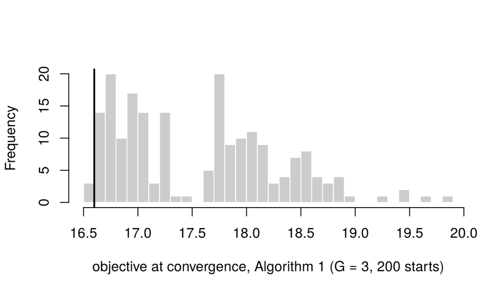

```r
hist(a1$objectives_by_start, breaks = 40, col = "gray80", border = "white",
     main = "", xlab = "objective at convergence, Algorithm 1 (G = 3, 200 starts)")
abline(v = min(a1$objectives_by_start), lwd = 2)
```

## 3.2 Algorithm 2: variable neighborhood search

Variable neighborhood search (VNS) adds two moves to Algorithm 1: a *local search* that tries to move each unit, one at a time, to every other group and keeps any move that lowers the objective; and random *jumps* that relocate $n = 1, 2, \dots$ units at once, to escape a local minimum. The tuning parameters $(N_s; n_{\max}; j_{\max})$ are the number of starts, the largest jump, and the number of passes without improvement. The paper uses $(10; 10; 10)$ for the main estimates and recommends checking that different starting values yield exactly the same solution.

```r
set.seed(2)
v3 <- gfe(p, G = 3, algorithm = "vns", n_starts = 3, neighmax = 10, itermax = 10)
v3
```

```
Grouped fixed-effects estimator (Bonhomme and Manresa, 2015)
  N = 90  T = 7  K = 2  G = 3
  computed with: Algorithm 2 (VNS)
  objective: 16.59872653
  group sizes: 24 28 38
  theta:
   lag_dem lag_income
    0.4065     0.0894
  starts reaching the best objective: 1 of 3 (33%)
```

The local search is cheap because the objective can be written in terms of group-by-period sums of $(y_{it}, x_{it}')'$ and their cross products, so moving one unit only updates two groups’ sums (see `gfe_stats()` in `R/gfe_core.R`).

## 3.3 Checking the heuristics: an exact solution

The Supplementary Appendix verifies the heuristics on subsamples where the global minimum can be certified, with an extension of Brusco’s (2006) branch and bound to models with covariates. For the first 30 countries and $G = 2$, the exact solution and both heuristics coincide (`scripts/03_exact_algorithm.R`; about a minute with the compiled engine). A toy version:

```r
set.seed(3)
toy <- gfe_panel(y = rnorm(40), X = matrix(rnorm(80), 40, 2), N = 10, T = 4)
c(brute_force    = gfe_bruteforce(toy, 2)$objective,          # all 2^10 groupings
  branch_bound   = gfe_exact_bb(toy, 2, engine = "R")$objective,
  vns            = gfe(toy, 2, n_starts = 2)$objective)
```

```
 brute_force branch_bound          vns
    14.31366     14.31366     14.31366
```

## 3.4 Does the search find the published solution?

The authors’ optimal groupings are hard-coded in their MATLAB files; we ship them in `data/bm_published_groupings.csv`. The VNS solution above should be the same partition of countries, up to a relabeling of the groups:

```r
pub <- load_bm_published()
f3  <- gfe(p, 3, groups = pub$groupings$G3)
c(published = f3$objective, vns = v3$objective)
```

```
published       vns
 16.59873  16.59873
```

```r
match_groups(v3$groups, f3$groups, 3)$misclassification
```

```
[1] 0
```

# 4 Estimates and the number of groups

Given the groupings, the estimates for $G = 1, \dots, 15$ follow in a fraction of a second. $G = 1$ is the model with common time effects and no unit effects.

```r
fits <- lapply(1:15, function(G)
  gfe(p, G, groups = if (G == 1) NULL else pub$groupings[[paste0("G", G)]]))
bic <- gfe_bic(fits)
cum <- function(th) th[2] / (1 - th[1])
est <- data.frame(G = 1:15,
                  objective  = sapply(fits, `[[`, "objective"),
                  BIC        = bic$BIC,
                  theta1     = sapply(fits, function(f) f$theta[1]),
                  theta2     = sapply(fits, function(f) f$theta[2]),
                  cumulative = sapply(fits, function(f) cum(f$theta)))
print(round(est, 3), row.names = FALSE)
```

```
  G objective   BIC theta1 theta2 cumulative
  1    24.301 0.052  0.665  0.083      0.246
  2    19.847 0.046  0.601  0.061      0.152
  3    16.599 0.041  0.406  0.089      0.151
  4    14.319 0.039  0.302  0.082      0.118
  5    12.593 0.037  0.255  0.079      0.106
  6    11.132 0.036  0.465  0.064      0.119
  7    10.059 0.035  0.403  0.065      0.108
  8     9.251 0.034  0.333  0.070      0.104
  9     8.426 0.034  0.312  0.069      0.101
 10     7.749 0.034  0.277  0.075      0.104
 11     7.218 0.034  0.293  0.073      0.104
 12     6.809 0.034  0.304  0.074      0.107
 13     6.391 0.035  0.236  0.072      0.094
 14     5.996 0.035  0.237  0.071      0.094
 15     5.664 0.035  0.244  0.071      0.094
```

These are the point estimates of Table S.XI. The BIC,

$$\mathrm{BIC}(G) = \frac{1}{NT} \hat Q(G) + \hat\sigma^2 \, \frac{GT + N
+ K}{NT} \, \ln(NT),
\qquad \hat\sigma^2 = \frac{\hat Q(G_{\max})}{NT - G_{\max}T - N - K},$$

selects $G = 10$. The paper’s headline results use $G = 4$, which is easier to interpret and gives very similar estimates of the income effect. Compare with the two benchmarks: the cumulative effect is 0.246 with common time effects only ($G = 1$), and with country fixed effects

```r
fe <- gfe(gfe_within(p), 1)
round(c(theta1 = fe$theta[[1]], theta2 = fe$theta[[2]], cumulative = cum(fe$theta)), 3)
```

```
               theta1                theta2 cumulative.lag_income
                0.283                -0.031                -0.044
```

GFE lands in between: allowing countries to follow a handful of distinct democratization paths roughly halves the pooled income effect, without wiping it out.

# 5 Inference

Theorem 2 of the paper shows that, as $N$ and $T$ grow with $N/T^\nu \to 0$ for some $\nu > 0$, misclassification vanishes fast enough for $\hat\theta$ to be asymptotically equivalent to OLS with the true groups. Standard errors can then be computed as if the estimated groups were known, clustering by unit (the “large-$T$” variance). With $T = 7$, that is optimistic. The paper also reports a fixed-$T$ variance, based on Pollard’s (1982) asymptotics for $k$-means, which accounts for units near the boundary between two groups, and a bootstrap that resamples whole countries.

```r
f4 <- fits[[4]]
cum_grad <- function(th) c(th[2] / (1 - th[1])^2, 1 / (1 - th[1]))
V_lt <- gfe_vcov_largeT(f4)
V_ft <- gfe_vcov_fixedT(f4, eps = gfe_bandwidth(f4))
boot <- subset(pub$bootstrap_se, G == 4)
se <- rbind(
  `large-T`   = c(gfe_se_theta(f4, V_lt), sqrt(gfe_delta(f4, V_lt, cum_grad(f4$theta)))),
  `fixed-T`   = c(gfe_se_theta(f4, V_ft), sqrt(gfe_delta(f4, V_ft, cum_grad(f4$theta)))),
  `bootstrap` = unlist(boot[, c("se_lag_dem", "se_lag_income", "se_cumulative_income")]))
colnames(se) <- c("theta1", "theta2", "cumulative")
round(rbind(estimate = c(theta1 = f4$theta[[1]], theta2 = f4$theta[[2]], cumulative = cum(f4$theta)), se), 3)
```

```
          theta1 theta2 cumulative.lag_income
estimate   0.302  0.082                 0.118
large-T    0.054  0.009                 0.011
fixed-T    0.108  0.012                 0.021
bootstrap  0.140  0.017                 0.038
```

The fixed-$T$ and bootstrap standard errors are larger than the large-$T$ ones. The Monte Carlo exercises of the Supplementary Appendix, calibrated to these data (`scripts/04_montecarlo.R`), show that the large-$T$ intervals undercover at this sample size, while the fixed-$T$ and bootstrap intervals have close to nominal coverage. (The bootstrap row uses the authors’ 100 replications; `gfe_bootstrap()` recomputes it.)

# 6 Grouped patterns of democracy

With $G = 4$ the estimated paths have a clear interpretation: a high-democracy group, a low-democracy group, and two groups that democratize, an “early transition” group in the 1970s and 1980s and a “late transition” group in the 1990s.

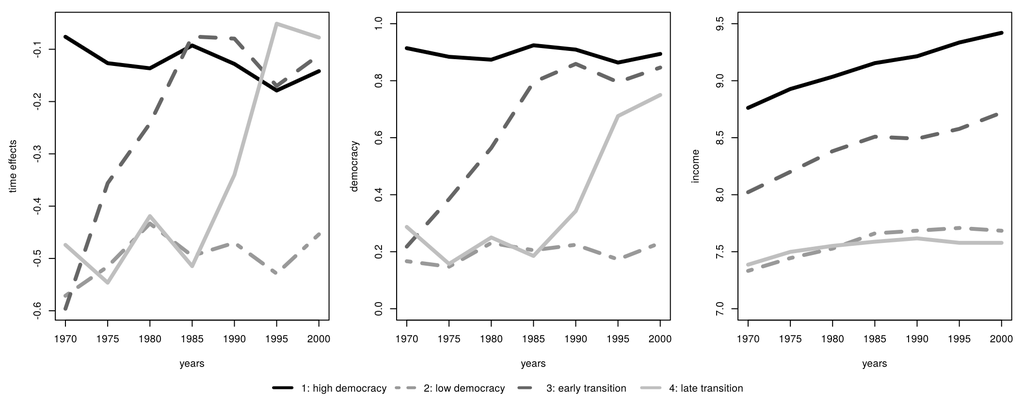

```r
paper_labels <- c(2, 3, 4, 1)      # published label -> paper's label (see scripts/02)
f4 <- gfe(p, 4, groups = paper_labels[pub$groupings$G4])
cols <- gray(c(0, 0.6, 0.4, 0.75)); ltys <- c(1, 4, 2, 1)
op <- par(mfrow = c(1, 3), mar = c(4.5, 4.5, 1, 1), oma = c(2, 0, 0, 0))
plot_profiles(f4$alpha, p$time_labels, ylab = "time effects", col = cols, lty = ltys)
plot_profiles(group_means(f4, p$y), p$time_labels, ylab = "democracy", ylim = c(0, 1), col = cols, lty = ltys)
plot_profiles(group_means(f4, p$X[, "lag_income"]), p$time_labels, ylab = "income", ylim = c(7, 9.5),
              col = cols, lty = ltys)
par(fig = c(0, 1, 0, 1), oma = c(0, 0, 0, 0), mar = c(0, 0, 0, 0), new = TRUE)
plot(0, 0, type = "n", axes = FALSE, xlab = "", ylab = "")
legend("bottom", c("1: high democracy", "2: low democracy", "3: early transition", "4: late transition"),
       col = cols, lty = ltys, lwd = 3, horiz = TRUE, bty = "n")
```

```r
par(op)
```

```r
split(names(f4$groups), factor(f4$groups, labels = c("high democracy", "low democracy", "early transition", "late transition")))
```

```
$`high democracy`
 [1] "AUS" "AUT" "BEL" "CAN" "CHE" "COL" "CRI" "CYP" "DNK" "DOM" "FIN" "FRA"
[13] "GBR" "GTM" "IND" "IRL" "ISL" "ISR" "ITA" "JAM" "JPN" "LKA" "LUX" "MYS"
[25] "NLD" "NOR" "NZL" "SLV" "SWE" "TTO" "TUR" "USA" "VEN"

$`low democracy`
 [1] "BDI" "CHN" "CIV" "CMR" "COG" "DZA" "EGY" "GAB" "GIN" "IDN" "IRN" "JOR"
[13] "KEN" "MAR" "MRT" "NGA" "PRY" "RWA" "SGP" "SLE" "SYR" "TCD" "TGO" "TUN"
[25] "UGA" "ZAR"

$`early transition`
 [1] "ARG" "BOL" "BRA" "ECU" "ESP" "GRC" "HND" "KOR" "NPL" "PER" "PRT" "THA"
[13] "URY"

$`late transition`
 [1] "BEN" "BFA" "CAF" "CHL" "GHA" "MDG" "MEX" "MLI" "MWI" "NER" "NIC" "PAN"
[13] "PHL" "ROM" "TWN" "TZA" "ZAF" "ZMB"
```

The time effects (left panel) are net of the effect of lagged democracy and income; the middle and right panels are raw group averages. In 1970 the late transition group looks much like the low-democracy group, in democracy and in income, yet the two paths separate sharply in the 1990s.

# 7 Robustness and extensions

The Supplementary Appendix asks whether this classification is an artifact of the specification. `scripts/05_extensions.R` reproduces each exercise:

- **Country fixed effects plus grouped patterns.** Applying GFE to deviations from country means removes time-invariant country effects. The income effect then disappears, as with fixed effects, but the classification into stable, early-transition, and late-transition countries survives: with $G = 3$ it agrees with the baseline $G = 4$ classification for 80 of the 90 countries.
- **Two layers of groups.** Within each of three time-varying groups, subgroups differ by a constant.
- **Heterogeneous coefficients.** Allowing the income coefficient (or both coefficients) to differ across groups leaves the grouped patterns intact.
- **Explaining group membership.** `scripts/06_explaining_the_waves.R` relates the groups to historical and economic covariates with multinomial logits: constraints on the executive at independence separate high- from low-democracy countries, but nothing in the list predicts which non-democracies transition.

# 8 Notes on the workflow

A few features of the paper and its replication files are worth imitating.

- *The estimator is an optimization problem first.* Everything (estimation, inference, model selection, extensions) is built on the same two steps: OLS given the groups, and assignment given the parameters.
- *Computation is checked, not assumed.* Many starting values, an explicit rule (“different starting values should yield the exact same solution”), and an exact algorithm to certify the heuristics on subsamples.
- *Theory is paired with a calibrated simulation.* The Monte Carlo design takes its parameters from the estimates on the actual data, so the finite-sample evidence speaks to the application at hand.
- *Robustness is organized around the main finding.* Each extension asks whether the grouped patterns survive a specific objection.

# 9 References

- Acemoglu, D., S. Johnson, J. A. Robinson, and P. Yared (2008), “Income and Democracy,” *American Economic Review* 98(3), 808–842.
- Bonhomme, S. and E. Manresa (2015), “Grouped Patterns of Heterogeneity in Panel Data,” *Econometrica* 83(3), 1147–1184, and Supplementary Appendix.
- Brusco, M. J. (2006), “A Repetitive Branch-and-Bound Procedure for Minimum Within-Cluster Sums of Squares Partitioning,” *Psychometrika* 71(2), 347–363.
- Hansen, P. and N. Mladenović (2001), “Variable Neighborhood Search: Principles and Applications,” *European Journal of Operational Research* 130(3), 449–467.
- Pollard, D. (1982), “A Central Limit Theorem for k-Means Clustering,” *Annals of Probability* 10(4), 919–926.